# Thesis_New Setup post-feedback

Juyoung Kim

2025-08-09

# Loading

```r
library(haven)      # For .sav file reading
library(dplyr)      # Data manipulation
library(tidyr)      # Data wrangling
```

```r
library(ggplot2)    # Visualization
library(psych)      # Summary stats
# save file path
path <- "./sharew7_rel9-0-0_ALL_datasets_spss"
```

Load datasets of SHARE Wave 7 [1]. The methodology document states what the specific variable names are for our interest factors [2].

```r
cf <- read_sav(paste0(path, "/sharew7_rel9-0-0_cf.sav"))
ac <- read_sav(paste0(path, "/sharew7_rel9-0-0_ac.sav"))
ex <- read_sav(paste0(path, "/sharew7_rel9-0-0_ex.sav"))
```

```r
cf <- read_sav(paste0(path, "/sharew7_rel9-0-0_cf.sav"))
ac <- read_sav(paste0(path, "/sharew7_rel9-0-0_ac.sav"))
ex <- read_sav(paste0(path, "/sharew7_rel9-0-0_ex.sav"))
cv_r <- read_sav(paste0(path, "/sharew7_rel9-0-0_cv_r.sav"))  # demographic info
gv_isced<-read_sav(paste0(path,"/sharew7_rel9-0-0_gv_isced.sav")) # for edu level
ph<-read_sav(paste0(path,"/sharew7_rel9-0-0_ph.sav")) #for health status
hh <- read_sav(paste0(path, "/sharew7_rel9-0-0_hh.sav")) #income

#-----After 2nd Meeting--------------#
# for CC728_ (importance of religion while growing up)
cc <- read_sav(paste0(path, "/sharew7_rel9-0-0_cc.sav"))
```

## 1. Merge Datasets

```r
df <- cf %>%
  left_join(ac, by = "mergeid") %>%
  left_join(ex, by = "mergeid") %>%
  left_join(cv_r, by = "mergeid") %>%
  left_join(gv_isced, by = "mergeid") %>%
  left_join(ph, by = "mergeid") %>%
  left_join(cc, by = "mergeid") %>%
  left_join(hh, by = "mergeid")
```

# Variable Pre-Inspection

Inspecting raw counts before merging & filtering

## 1. Helper Function

Inspect raw and valid values of a variable

```r
# separate valid vs. invalid (< 0)
inspect <- function(var, var_name = deparse(substitute(var))) {
  cat("\n======================\n")
  cat("Inspecting:", var_name, "\n\n")
  cat("All responses:\n")
  print(table(var, useNA = "ifany"))
  print(summary(var))
  cat("Non-missing:", sum(!is.na(var)), "\n\n")
  valid <- var[!is.na(var) & var >= 0]
  cat("Valid responses:\n")
  print(table(valid))
  print(summary(valid))
  cat("Valid count:", length(valid), "\n")
  cat("======================\n")
}
```

## 2. Key Vars

```r
# Religiousness
inspect(ex$ex029_, var_name = "Frequency of Prayer (ex029_)")
```

```
##
## ======================
## Inspecting: Frequency of Prayer (ex029_)
##
## All responses:
## var
##    -2    -1     1     2     3     4     5     6  <NA>
##     2    20    58    74    53    41    73   136 76724
##    Min. 1st Qu.  Median    Mean 3rd Qu.    Max.    NA's
##   -2.00    2.00    4.00    3.69    6.00    6.00   76724
## Non-missing: 457
##
## Valid responses:
## valid
##   1   2   3   4   5   6
##  58  74  53  41  73 136
##    Min. 1st Qu.  Median    Mean 3rd Qu.    Max.
##   1.000   2.000   4.000   3.931   6.000   6.000
## Valid count: 435
## ======================
```

```r
inspect(cc$cc728_, var_name = "Childhood Religion Importance (cc728_)")
```

```
##
## ======================
## Inspecting: Childhood Religion Importance (cc728_)
##
## All responses:
## var
##    -2    -1     1     2     3     4  <NA>
##    43  1158 18304 19687 13354 10532 14103
##    Min. 1st Qu.  Median    Mean 3rd Qu.    Max.    NA's
##  -2.000   1.000   2.000   2.198   3.000   4.000   14103
## Non-missing: 63078
##
## Valid responses:
## valid
##     1     2     3     4
## 18304 19687 13354 10532
##    Min. 1st Qu.  Median    Mean 3rd Qu.    Max.
##    1.00    1.00    2.00    2.26    3.00    4.00
## Valid count: 61877
## ======================
```

```r
# Life satisfaction
inspect(ac$ac012_, var_name = "Life Satisfaction (ac012_)")
```

```
##
## ======================
## Inspecting: Life Satisfaction (ac012_)
##
## All responses:
## var
##    -2    -1     0     1     2     3     4     5     6     7     8     9    10
##   127  2303   484   286   549  1059  1491  7569  5634 12272 22538 11145 11504
##  <NA>
##   220
##    Min. 1st Qu.  Median    Mean 3rd Qu.    Max.    NA's
##  -2.000   6.000   8.000   7.292   9.000  10.000     220
## Non-missing: 76961
##
## Valid responses:
## valid
##     0     1     2     3     4     5     6     7     8     9    10
##   484   286   549  1059  1491  7569  5634 12272 22538 11145 11504
##    Min. 1st Qu.  Median    Mean 3rd Qu.    Max.
##   0.000   7.000   8.000   7.564   9.000  10.000
## Valid count: 74531
## ======================
```

### Cognitive Skills

```r
# Memory
memory_vars <- c("cf104tot", "cf105tot", "cf106tot", "cf107tot",
                 "cf113tot", "cf114tot", "cf115tot", "cf116tot")
cat("\nMemory Items:\n")
```

```
##
## Memory Items:
```

```r
sapply(cf[memory_vars], function(x) sum(!is.na(x)))
```

```
## cf104tot cf105tot cf106tot cf107tot cf113tot cf114tot cf115tot cf116tot
##    18470    18626    18598    18623    18563    18723    18677    18716
```

```r
# Verbal fluency
inspect(cf$cf010_, var_name = "Verbal Fluency (cf010_)")
```

```
##
## ======================
## Inspecting: Verbal Fluency (cf010_)
##
## All responses:
## var
##    -2    -1     0     1     2     3     4     5     6     7     8     9    10
##    22    26    93    26    30    50    69   115   194   223   285   351   468
##    11    12    13    14    15    16    17    18    19    20    21    22    23
##   519   618   580   649   747   693   658   698   608   675   572   549   535
##    24    25    26    27    28    29    30    31    32    33    34    35    36
##   485   471   398   347   296   221   277   171   189   132   101   104    59
##    37    38    39    40    41    42    43    44    45    46    47    48    50
##    45    40    33    38    18    19     9     7    13     7     4     1     4
##    51    52    54    55    57    59    60    61    63    65    70    80    88
##     2     1     1     2     1     1     2     1     1     1     3     2     1
##    93   100  <NA>
##     5     4 63611
##    Min. 1st Qu.  Median    Mean 3rd Qu.    Max.    NA's
##    -2.0    13.0    18.0    18.7    24.0   100.0   63611
## Non-missing: 13570
##
## Valid responses:
## valid
##   0   1   2   3   4   5   6   7   8   9  10  11  12  13  14  15  16  17  18  19
##  93  26  30  50  69 115 194 223 285 351 468 519 618 580 649 747 693 658 698 608
##  20  21  22  23  24  25  26  27  28  29  30  31  32  33  34  35  36  37  38  39
## 675 572 549 535 485 471 398 347 296 221 277 171 189 132 101 104  59  45  40  33
##  40  41  42  43  44  45  46  47  48  50  51  52  54  55  57  59  60  61  63  65
##  38  18  19   9   7  13   7   4   1   4   2   1   1   2   1   1   2   1   1   1
##  70  80  88  93 100
##   3   2   1   5   4
##    Min. 1st Qu.  Median    Mean 3rd Qu.    Max.
##    0.00   13.00   18.00   18.77   24.00  100.00
## Valid count: 13522
## ======================
```

```r
# Numeracy
numeracy_vars <- c("cf012_", "cf013_", "cf014_", "cf015_")
cat("\nNumeracy Items:\n")
```

```
##
## Numeracy Items:
```

```r
sapply(cf[numeracy_vars], function(x) sum(!is.na(x)))
```

```
## cf012_ cf013_ cf014_ cf015_
##    457    120    337    162
```

According to the routing of CF [3]:

- The whole participants of CF were assigned to 2 different groups (Test-history & Test-regular) - according to prior participation & cognitive testing history in past SHARE waves.
  - Test-History Group: Returning participants. Were assigned to a lighter version: Memory (Immediate & delayed), Did not receive the numeracy/verbal fluency tasks.
  - Test-Regular Group: People who did not take the full tests before. Got full cognitive questions (M, N, VF) IF MN101_longitudinal=0 AND MN103_History=0
- **Memory** - randomly assigned to 4 sub-groups
- **Numeracy** - participant needed to correctly answer previous (Numeracy) question in order to proceed to the next N questions (conditional branching: cf012 (correct) > cf014 > cf015 or cf012(wrong) > cf013)

## 3. Control Vars

```r
# Demographics
inspect(cv_r$age2017, var_name = "Age")
```

```
##
## ======================
## Inspecting: Age
##
## All responses:
## var
##   -9    0    1    2    3    4    5    6    7    8    9   10   11   12   13   14
## 4251   58  104  120  117  119  151  128  146  160  184  199  193  224  228  240
##   15   16   17   18   19   20   21   22   23   24   25   26   27   28   29   30
##  352  356  481  505  545  567  583  624  631  646  656  683  681  578  603  579
##   31   32   33   34   35   36   37   38   39   40   41   42   43   44   45   46
##  489  493  447  469  436  396  418  369  397  372  374  400  407  354  378  416
##   47   48   49   50   51   52   53   54   55   56   57   58   59   60   61   62
##  453  479  525  603  944 1075 1586 1774 2167 2381 2786 2744 2798 2884 3062 3238
##   63   64   65   66   67   68   69   70   71   72   73   74   75   76   77   78
## 3242 3135 3216 3135 3239 3056 3152 2949 2915 2467 2586 2351 2199 2123 2189 1957
##   79   80   81   82   83   84   85   86   87   88   89   90   91   92   93   94
## 1906 1748 1588 1519 1350 1175 1110  972  866  691  609  486  381  317  240  168
##   95   96   97   98   99  100  101  102  103  104  105  113 <NA>
##  115   96   72   25   16    8   13    4    2    1    2    1  331
##    Min. 1st Qu.  Median    Mean 3rd Qu.    Max.    NA's
##   -9.00   53.00   64.00   58.37   73.00  113.00     331
## Non-missing: 111198
##
## Valid responses:
## valid
##    0    1    2    3    4    5    6    7    8    9   10   11   12   13   14   15
##   58  104  120  117  119  151  128  146  160  184  199  193  224  228  240  352
##   16   17   18   19   20   21   22   23   24   25   26   27   28   29   30   31
##  356  481  505  545  567  583  624  631  646  656  683  681  578  603  579  489
##   32   33   34   35   36   37   38   39   40   41   42   43   44   45   46   47
##  493  447  469  436  396  418  369  397  372  374  400  407  354  378  416  453
##   48   49   50   51   52   53   54   55   56   57   58   59   60   61   62   63
##  479  525  603  944 1075 1586 1774 2167 2381 2786 2744 2798 2884 3062 3238 3242
##   64   65   66   67   68   69   70   71   72   73   74   75   76   77   78   79
## 3135 3216 3135 3239 3056 3152 2949 2915 2467 2586 2351 2199 2123 2189 1957 1906
##   80   81   82   83   84   85   86   87   88   89   90   91   92   93   94   95
## 1748 1588 1519 1350 1175 1110  972  866  691  609  486  381  317  240  168  115
##   96   97   98   99  100  101  102  103  104  105  113
##   96   72   25   16    8   13    4    2    1    2    1
##    Min. 1st Qu.  Median    Mean 3rd Qu.    Max.
##    0.00   55.00   64.00   61.05   73.00  113.00
## Valid count: 106947
## ======================
```

```r
inspect(cv_r$gender, var_name = "Gender")
```

```
##
## ======================
## Inspecting: Gender
##
## All responses:
## var
##     1     2
## 51368 60161
##    Min. 1st Qu.  Median    Mean 3rd Qu.    Max.
##   1.000   1.000   2.000   1.539   2.000   2.000
## Non-missing: 111529
##
## Valid responses:
## valid
##     1     2
## 51368 60161
##    Min. 1st Qu.  Median    Mean 3rd Qu.    Max.
##   1.000   1.000   2.000   1.539   2.000   2.000
## Valid count: 111529
## ======================
```

```r
inspect(cv_r$country, var_name = "Country")
```

```
##
## ======================
## Inspecting: Country
##
## All responses:
## var
##   11   12   13   15   16   17   18   19   20   23   25   28   29   31   32   33
## 4135 4928 4075 7348 6850 4530 4429 4390 3273 7076 3180 5674 8132 2027 2599 1964
##   34   35   47   48   51   53   55   57   59   61   63
## 5828 6922 3885 2858 2617 1848 2586 2296 1883 3385 2811
##    Min. 1st Qu.  Median    Mean 3rd Qu.    Max.
##    11.0    17.0    28.0    29.5    35.0    63.0
## Non-missing: 111529
##
## Valid responses:
## valid
##   11   12   13   15   16   17   18   19   20   23   25   28   29   31   32   33
## 4135 4928 4075 7348 6850 4530 4429 4390 3273 7076 3180 5674 8132 2027 2599 1964
##   34   35   47   48   51   53   55   57   59   61   63
## 5828 6922 3885 2858 2617 1848 2586 2296 1883 3385 2811
##    Min. 1st Qu.  Median    Mean 3rd Qu.    Max.
##    11.0    17.0    28.0    29.5    35.0    63.0
## Valid count: 111529
## ======================
```

```r
# Education
inspect(gv_isced$isced2011_r, var_name = "Education")
```

```
##
## ======================
## Inspecting: Education
##
## All responses:
## var
##    -2    -1     0     1     2     3     4     5     6     7     8    95    97
##     8     8  2108  4881  6477 16298  1998  2606  2965  3157   259     2    24
##  <NA>
## 36390
##    Min. 1st Qu.  Median    Mean 3rd Qu.    Max.    NA's
##   -2.00    2.00    3.00    3.24    4.00   97.00   36390
## Non-missing: 40791
##
## Valid responses:
## valid
##     0     1     2     3     4     5     6     7     8    95    97
##  2108  4881  6477 16298  1998  2606  2965  3157   259     2    24
##    Min. 1st Qu.  Median    Mean 3rd Qu.    Max.
##   0.000   2.000   3.000   3.243   4.000  97.000
## Valid count: 40775
## ======================
```

```r
# Health
inspect(ph$ph003_, var_name = "Health Status")
```

```
##
## ======================
## Inspecting: Health Status
##
## All responses:
## var
##    -2    -1     1     2     3     4     5  <NA>
##    18   153  4442 11936 27883 22851  9689   209
##    Min. 1st Qu.  Median    Mean 3rd Qu.    Max.    NA's
##  -2.000   3.000   3.000   3.269   4.000   5.000     209
## Non-missing: 76972
##
## Valid responses:
## valid
##     1     2     3     4     5
##  4442 11936 27883 22851  9689
##    Min. 1st Qu.  Median    Mean 3rd Qu.    Max.
##   1.000   3.000   3.000   3.279   4.000   5.000
## Valid count: 76801
## ======================
```

```r
# Income
summary(hh$hh017e)
```

```
##       Min.    1st Qu.     Median       Mean    3rd Qu.       Max.       NA's
## -1.000e+07  3.500e+02  9.500e+02 -1.190e+06  2.024e+03  1.000e+10      25140
```

```r
cat("Non-NA count (incl. negative codes):", sum(!is.na(hh$hh017e)), "\n")
```

```
## Non-NA count (incl. negative codes): 52041
```

```r
# Valid responses: income >= 0
valid_income <- hh$hh017e[!is.na(hh$hh017e) & hh$hh017e >= 0]
cat("Valid count (income):", length(valid_income), "\n")
```

```
## Valid count (income): 43531
```

# Variable Construction

## 1. Key Variables

### 1) Religiousness

**Frequency of prayer:** ex029 [4]

- 1: More than once a day
- 2: Once daily
- 3: A couple of times a week
- 4: Once a week
- 5: Less than once a week
- 6: Never

-> Disregarded the approach because of too small sample size

**Childhood importance of Religion:** cc728_ [5]

- 1: Very important
- 2: Somewhat important
- 3: Not very important
- 4: Not at all important

```r
table(df$cc728_)  #Need to remove -2 and -1
```

```
##
##    -2    -1     1     2     3     4
##    43  1158 18304 19687 13354 10532
```

```r
# Create a temporary indicator
df <- df %>%
  mutate(child_sig = ifelse(cc728_ >= 1, cc728_, NA))  # keep other vars

table(df$child_sig)
```

```
##
##     1     2     3     4
## 18304 19687 13354 10532
```

```r
# reverse child_sig code (1 to 4 becomes 4: Not at all important to 1: Very Important)
df <- df %>%
  mutate(child_sig_rev = 5 - child_sig)

table(df$child_sig_rev)
```

```
##
##     1     2     3     4
## 10532 13354 19687 18304
```

```r
df$child_sig <- df$child_sig_rev
table(df$child_sig_rev)
```

```
##
##     1     2     3     4
## 10532 13354 19687 18304
```

### 2) Cognitive Skills

1 person receives 1 pair of memory tasks (immediate + delayed recall) [3]

#### a.1) Memory recall (immediate)

```r
df <- df %>%
  mutate(mem_immediate = coalesce(cf104tot, cf105tot, cf106tot, cf107tot))

table(df$mem_immediate)
```

```
##
##     0     1     2     3     4     5     6     7     8     9    10
##  1872  1116  2892  6997 12697 16845 15397 10088  4557  1383   473
```

#### a.2) Memory recall (delayed)

```r
df <- df %>%
  mutate(mem_delayed = coalesce(cf113tot, cf114tot, cf115tot, cf116tot))

table(df$mem_delayed)
```

```
##
##     0     1     2     3     4     5     6     7     8     9    10
##  7586  4859  8601 12822 13974 12022  7616  4077  1891   816   415
```

#### a.3) Memory average score

```r
df <- df %>%
  mutate(mem_avg = rowMeans(cbind(mem_immediate, mem_delayed), na.rm = TRUE))

table(df$mem_avg)
```

```
##
##    0  0.5    1  1.5    2  2.5    3  3.5    4  4.5    5  5.5    6  6.5    7  7.5
## 2219  644 1555 2369 3334 4119 5554 6341 7890 7907 8126 6767 6060 4097 3112 1874
##    8  8.5    9  9.5   10
## 1240  689  457  187  177
```

```r
sum(!is.na(df$mem_avg))
```

```
## [1] 74718
```

All individuals assigned to CF module received the memory related Questions.

#### b) Verbal Fluency

Not assigned to Test-History group.

```r
table(df$cf010_)
```

```
##
##  -2  -1   0   1   2   3   4   5   6   7   8   9  10  11  12  13  14  15  16  17
##  22  26  93  26  30  50  69 115 194 223 285 351 468 519 618 580 649 747 693 658
##  18  19  20  21  22  23  24  25  26  27  28  29  30  31  32  33  34  35  36  37
## 698 608 675 572 549 535 485 471 398 347 296 221 277 171 189 132 101 104  59  45
##  38  39  40  41  42  43  44  45  46  47  48  50  51  52  54  55  57  59  60  61
##  40  33  38  18  19   9   7  13   7   4   1   4   2   1   1   2   1   1   2   1
##  63  65  70  80  88  93 100
##   1   1   3   2   1   5   4
```

```r
summary(df$cf010_)
```

```
##    Min. 1st Qu.  Median    Mean 3rd Qu.    Max.    NA's
##    -2.0    13.0    18.0    18.7    24.0   100.0   63611
```

```r
sum(!is.na(df$cf010_))
```

```
## [1] 13570
```

#### c) Numeracy

```r
summary(df$cf012_)
```

```
##    Min. 1st Qu.  Median    Mean 3rd Qu.    Max.    NA's
##   -2.00    1.00    1.00    9.67    1.00   97.00   76724
```

```r
summary(df$cf013_)
```

```
##    Min. 1st Qu.  Median    Mean 3rd Qu.    Max.    NA's
##   -2.00   -1.00    1.00   10.87    1.00   97.00   77061
```

```r
summary(df$cf014_)
```

```
##    Min. 1st Qu.  Median    Mean 3rd Qu.    Max.    NA's
##   -2.00    1.00    1.00   17.33    5.00   97.00   76844
```

```r
summary(df$cf015_)
```

```
##    Min. 1st Qu.  Median    Mean 3rd Qu.    Max.    NA's
##   -2.00    1.00    5.00   10.54    6.00   97.00   77019
```

```r
sum(!is.na(df$cf012_))
```

```
## [1] 457
```

```r
sum(!is.na(df$cf013_))
```

```
## [1] 120
```

```r
sum(!is.na(df$cf014_))
```

```
## [1] 337
```

```r
sum(!is.na(df$cf014_))
```

```
## [1] 337
```

```r
sum(!is.na(df$cf012_))+sum(!is.na(df$cf013_)) +sum(!is.na(df$cf014_)) +sum(!is.na(df$cf014_))
```

```
## [1] 1251
```

```r
df <- df %>%
  mutate(across(c(cf012_, cf013_, cf014_, cf015_), ~ ifelse(. < 0, NA, .))) %>%
  mutate(
    cf012_score = ifelse(cf012_ == 1, 1, 0),

    # If CF012 wrong → CF013
    cf013_score = ifelse(cf012_ == 0 & cf013_ == 1, 1, 0),

    # If CF012 correct → CF014 correct ->  CF015
    cf014_score = ifelse(cf012_ == 1 & cf014_ == 1, 1, 0),
    cf015_score = ifelse(cf012_ == 1 & cf014_ == 1 & cf015_ == 1, 1, 0)
  ) %>%
  mutate(
    numeracy = cf012_score + cf013_score + cf014_score + cf015_score
  )


table(df$numeracy)
```

```
##
##   0   1   2   3
##  69 157 109  49
```

Not many respondents because of the routing. Only Test-regular > (MN101_Longitudinal = 0) AND (MN103_History = 0) respondents receive the Numeracy tasks.

#### Final Composite Cognitive Index

Decided to only use memory average for the composite cognitive index

```r
df <- df %>%
  mutate(
    cog_index = as.numeric(scale(mem_avg))
  )

summary(df$cog_index)
```

```
##    Min. 1st Qu.  Median    Mean 3rd Qu.    Max.    NA's
## -2.2977 -0.7299  0.0540  0.0000  0.5766  2.9284    2463
```

```r
sum(!is.na(df$cog_index))
```

```
## [1] 74718
```

### 3) Life Satisfaction

Scale of 0~10 [6].

```r
df <- df %>%
  rename(ls = ac012_) %>%
  filter(ls >= 0 & ls <= 10)

table(df$ls)
```

```
##
##     0     1     2     3     4     5     6     7     8     9    10
##   484   286   549  1059  1491  7569  5634 12272 22538 11145 11504
```

## 2. Control Variables

### Gender

```r
df <- df %>%
  mutate(
    gender = factor(gender, levels = c(1, 2), labels = c("male", "female"))
  )
```

### Country

```r
df <- df %>%
  rename(country = country.y.y) %>%
  mutate(
    country = as.factor(country)
  )

#   `25` = "Israel"
df <- df %>% filter(country != 25)
```

### Age groups

```r
df <- df %>%  rename(age = age2017)
```

```r
table(df$age)
```

```
##
##   22   27   30   31   33   34   35   36   37   38   39   40   41   42   43   44
##    1    1    2    2    4    4   10    5    7   12   11   14   17   29   33   42
##   45   46   47   48   49   50   51   52   53   54   55   56   57   58   59   60
##   60   81  110  152  201  261  635  706 1223 1348 1709 1880 2233 2239 2298 2349
##   61   62   63   64   65   66   67   68   69   70   71   72   73   74   75   76
## 2530 2678 2716 2618 2738 2657 2778 2639 2707 2533 2508 2161 2236 2074 1923 1825
##   77   78   79   80   81   82   83   84   85   86   87   88   89   90   91   92
## 1880 1653 1594 1457 1340 1254 1073  949  870  773  659  514  441  337  256  227
##   93   94   95   96   97   98   99  100  101  102  105
##  154   93   61   51   37   15    8    3    5    1    1
```

Need to filter out people under 50.

```r
df <- df %>% filter(age >= 50)
```

```r
df <- df %>%
  mutate(
    age_group = case_when(
      age < 65 ~ "Under 65",
      age >= 65 & age < 75 ~ "65 to 74",
      age >= 75 ~ "Plus 75",
      TRUE ~ NA_character_
    )
  )
```

### Income

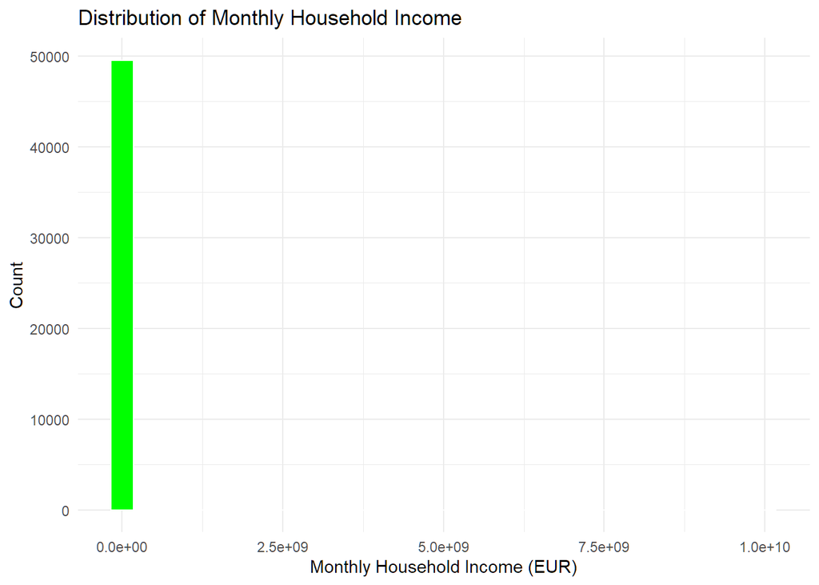

```r
df <- df %>%
  rename(income = hh017e )

ggplot(df, aes(x = income)) +
 geom_histogram(bins = 30, fill = "green", color = "white") +
 labs(
 title = "Distribution of Monthly Household Income",
 x = "Monthly Household Income (EUR)",
 y = "Count"
 ) +
 theme_minimal()
```

Extremely disproportionate distribution

```r
#check extreme values
quantile(df$income, probs = c(0.99, 0.995), na.rm = TRUE)
```

```
##   99% 99.5%
## 15000 27000
```

Use 27000 as the threshold.

```r
df <- df %>%
  mutate(
    income = ifelse(income < 0 | income > 26985.7 , NA, income)
  )

# income group by country
df <- df %>%
  group_by(country) %>%
  mutate(income_group = ntile(income, 4)) %>%
  ungroup()
```

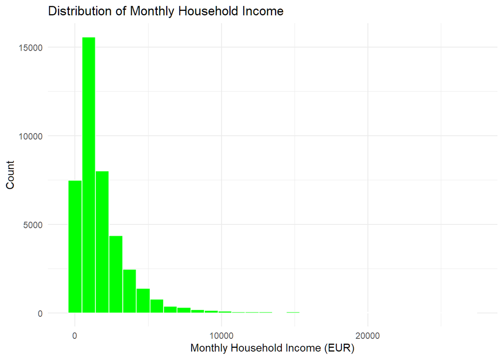

```r
# New histrogram
ggplot(df, aes(x = income)) +
 geom_histogram(bins = 30, fill = "green", color = "white") +
 labs(
 title = "Distribution of Monthly Household Income",
 x = "Monthly Household Income (EUR)",
 y = "Count"
 ) +
 theme_minimal()
```

### Education

```r
df <- df %>%
  rename(edu = isced2011_r) %>%
  filter(edu >= 0 & edu <= 8)

table(df$edu)
```

```
##
##     0     1     2     3     4     5     6     7     8
##  1860  4604  6087 15523  1899  2409  2743  2911   244
```

```r
df <- df %>%
  mutate(
    edu_label = case_when(
      edu == 0 ~ "Early childhood",
      edu == 1 ~ "Primary",
      edu == 2 ~ "Lower secondary",
      edu == 3 ~ "Upper secondary",
      edu == 4 ~ "Post-secondary non-tertiary",
      edu == 5 ~ "Short-cycle tertiary",
      edu == 6 ~ "Bachelor or equivalent",
      edu == 7 ~ "Master or equivalent",
      edu == 8 ~ "Doctoral or equivalent"
    )
  )
```

```r
df <- df %>%
  mutate(
    edu_group = case_when(
      edu <= 2 ~ "Low",
      edu == 3 ~ "Medium",
      edu >= 4 ~ "High"
    )
  )
```

### Health

```r
df <- df %>%
  rename(health = ph003_) %>%
  filter(health > 0)

table(df$health)  # need to remove -2 and -1
```

```
##
##     1     2     3     4     5
##  2436  6137 14234 11051  4408
```

```r
# Reverse code health (1 to 5 -> 5 to 1)
df <- df %>%
  mutate(health_rev = 6 - health)

table(df$health_rev)
```

```
##
##     1     2     3     4     5
##  4408 11051 14234  6137  2436
```

```r
df$health <- df$health_rev
table(df$health)
```

```
##
##     1     2     3     4     5
##  4408 11051 14234  6137  2436
```

```r
#re-create labels
df <- df %>%
  mutate(
    health_label = case_when(
      health == 1 ~ "Poor",
      health == 2 ~ "Fair",
      health == 3 ~ "Good",
      health == 4 ~ "Very good",
      health == 5 ~ "Excellent"
    )
  )
```

### Country & child_sig

```r
df$country <- dplyr::recode(df$country,
  `11` = "Austria",
  `12` = "Germany",
  `13` = "Sweden",
  `14` = "Netherlands",
  `15` = "Spain",
  `16` = "Italy",
  `17` = "France",
  `18` = "Denmark",
  `19` = "Greece",
  `20` = "Switzerland",
  `23` = "Belgium",
  `25` = "Israel",
  `28` = "Czech Republic",
  `29` = "Poland",
  `31` = "Luxembourg",
  `32` = "Hungary",
  `33` = "Portugal",
  `34` = "Slovenia",
  `35` = "Estonia",
  `47` = "Croatia",
  `48` = "Lithuania",
  `51` = "Bulgaria",
  `53` = "Cyprus",
  `55` = "Finland",
  `57` = "Latvia",
  `59` = "Malta",
  `61` = "Romania",
  `63` = "Slovakia"
)
```

```r
# Frequency Table by Country
df %>%
  filter(!is.na(child_sig)) %>%
  group_by(country, child_sig) %>%
  summarise(n = n()) %>%
  tidyr::pivot_wider(names_from = child_sig, values_from = n, values_fill = 0) %>%
  arrange(country)
```

```
## # A tibble: 26 × 5
## # Groups:   country [26]
##    country       `1`   `2`   `3`   `4`
##    <fct>       <int> <int> <int> <int>
##  1 Austria        15    46    40    51
##  2 Germany       560   594   940   734
##  3 Sweden        519   679   347   132
##  4 Spain         216   525   818   440
##  5 Italy          98   277   857   736
##  6 France         64   116   110    61
##  7 Denmark       412   559   382   160
##  8 Greece         11    61   224   638
##  9 Switzerland     8    36    33    27
## 10 Belgium       258   279   568   547
## # ℹ 16 more rows
```

```r
# Missingness by Country
df %>%
  mutate(child_sig_missing = is.na(child_sig)) %>%
  count(country, child_sig_missing) %>%
  tidyr::complete(country, child_sig_missing = c(TRUE, FALSE), fill = list(n = 0)) %>%
  pivot_wider(names_from = child_sig_missing, values_from = n) %>%
  rename(valid = `FALSE`, missing = `TRUE`)
```

```
## # A tibble: 27 × 3
##    country     valid missing
##    <fct>       <int>   <int>
##  1 Austria       152      29
##  2 Germany      2828      36
##  3 Sweden       1677      55
##  4 Spain        1999     126
##  5 Italy        1968      62
##  6 France        351      46
##  7 Denmark      1513      31
##  8 Greece        934      12
##  9 Switzerland   104      26
## 10 Belgium      1652      40
## # ℹ 17 more rows
```

No country has less than 30 valid observations. -> should just keep for now

-> **Feedback**: should use 100 instead of 30

## Incorporate Feedback (6/26)

### a. religiousness - 2 categories

```r
# Binary prayer categories relative to country mean
df <- df %>%
  group_by(country) %>%
  mutate(mean_child_sig_country = mean(child_sig, na.rm = TRUE)) %>%
  ungroup() %>%
  mutate(
    rel_cat = case_when(
      is.na(child_sig) ~ NA_character_,
      child_sig < mean_child_sig_country ~ "below_avg",
      TRUE ~ "above_avg"
    ),
    rel_above = ifelse(rel_cat == "above_avg", 1, ifelse(is.na(rel_cat), NA, 0)),
    rel_below = ifelse(rel_cat == "below_avg", 1, ifelse(is.na(rel_cat), NA, 0))
  )
```

### b. Cognitive Skills - 2 categories

```r
# cognitive category dummies relative to country mean (25~75 percentile)
df <- df %>%
  group_by(country) %>%
  mutate(
    cog_p25 = quantile(cog_index, 0.25, na.rm = TRUE),
    cog_p75 = quantile(cog_index, 0.75, na.rm = TRUE)
  ) %>%
  ungroup() %>%
  mutate(
    cog_cat = case_when(
      is.na(cog_index) ~ NA_character_,
      cog_index < cog_p25 ~ "below_avg",
      cog_index > cog_p75 ~ "above_avg",
      TRUE ~ "mid"
    ),
    cog_below = ifelse(cog_cat == "below_avg", 1, ifelse(is.na(cog_cat), NA, 0)),
    cog_above = ifelse(cog_cat == "above_avg", 1, ifelse(is.na(cog_cat), NA, 0))
  )
```

## Incorporate Feedback 7/9

### Compare child_sig and rel_above

```r
# number of valid counts for each variable
total_child_sig <- sum(!is.na(df$child_sig))
print(total_child_sig)
```

```
## [1] 37625
```

```r
total_rel_above <- sum(!is.na(df$rel_above))
print(total_rel_above)
```

```
## [1] 37625
```

```r
#number valid counts
total_child_sig <- sum(!is.na(df$child_sig))
total_rel_above <- sum(!is.na(df$rel_above))
total_rel_below <- sum(!is.na(df$rel_below))

# summary table
country_dist_summary <- df %>%
  group_by(country) %>%
  summarise(
    `child_sig (n)` = sum(!is.na(child_sig)),
    `child_sig (%)` = round(100 * sum(!is.na(child_sig)) / total_child_sig, 2),

    `rel_above (n)` = sum(!is.na(rel_above)),
    `rel_above (%)` = round(100 * sum(!is.na(rel_above)) / total_rel_above, 2),

    `rel_below (n)` = sum(!is.na(rel_below)),
    `rel_below (%)` = round(100 * sum(!is.na(rel_below)) / total_rel_below, 2)
  ) %>%
  arrange(desc(`child_sig (n)`))

# summary table
knitr::kable(
  country_dist_summary,
  caption = "Valid Counts and Percentages by Country for 'child_sig', 'rel_above', and 'rel_below'"
)
```

Valid Counts and Percentages by Country for ‘child_sig’, ‘rel_above’, and ‘rel_below’

| country | child_sig (n) | child_sig (%) | rel_above (n) | rel_above (%) | rel_below (n) | rel_below (%) |
| --- | --- | --- | --- | --- | --- | --- |
| Poland | 3316 | 8.81 | 3316 | 8.81 | 3316 | 8.81 |
| Germany | 2828 | 7.52 | 2828 | 7.52 | 2828 | 7.52 |
| Croatia | 2336 | 6.21 | 2336 | 6.21 | 2336 | 6.21 |
| Romania | 2043 | 5.43 | 2043 | 5.43 | 2043 | 5.43 |
| Spain | 1999 | 5.31 | 1999 | 5.31 | 1999 | 5.31 |
| Slovakia | 1994 | 5.30 | 1994 | 5.30 | 1994 | 5.30 |
| Lithuania | 1974 | 5.25 | 1974 | 5.25 | 1974 | 5.25 |
| Italy | 1968 | 5.23 | 1968 | 5.23 | 1968 | 5.23 |
| Finland | 1957 | 5.20 | 1957 | 5.20 | 1957 | 5.20 |
| Slovenia | 1928 | 5.12 | 1928 | 5.12 | 1928 | 5.12 |
| Bulgaria | 1926 | 5.12 | 1926 | 5.12 | 1926 | 5.12 |
| Sweden | 1677 | 4.46 | 1677 | 4.46 | 1677 | 4.46 |
| Belgium | 1652 | 4.39 | 1652 | 4.39 | 1652 | 4.39 |
| Latvia | 1649 | 4.38 | 1649 | 4.38 | 1649 | 4.38 |
| Denmark | 1513 | 4.02 | 1513 | 4.02 | 1513 | 4.02 |
| Malta | 1233 | 3.28 | 1233 | 3.28 | 1233 | 3.28 |
| Luxembourg | 1166 | 3.10 | 1166 | 3.10 | 1166 | 3.10 |
| Cyprus | 1158 | 3.08 | 1158 | 3.08 | 1158 | 3.08 |
| Czech Republic | 977 | 2.60 | 977 | 2.60 | 977 | 2.60 |
| Greece | 934 | 2.48 | 934 | 2.48 | 934 | 2.48 |
| Estonia | 640 | 1.70 | 640 | 1.70 | 640 | 1.70 |
| France | 351 | 0.93 | 351 | 0.93 | 351 | 0.93 |
| Austria | 152 | 0.40 | 152 | 0.40 | 152 | 0.40 |
| Portugal | 111 | 0.30 | 111 | 0.30 | 111 | 0.30 |
| Switzerland | 104 | 0.28 | 104 | 0.28 | 104 | 0.28 |
| Hungary | 39 | 0.10 | 39 | 0.10 | 39 | 0.10 |

# Data Selection & Cleaning

```r
#convert demographic variables
 df<-df%>%
 mutate(
 age= as.numeric(age),
 gender= factor(gender),
 income= as.numeric(income)
 )
```

```r
#Should filter out NAs & only keep interest variables
df <- df %>%
  dplyr::select(
    child_sig, cog_index, ls,
    age, age_group, gender,
    country,
    edu, edu_label, edu_group,
    health, health_label,
    income, income_group,
    rel_above, rel_below,
    cog_above, cog_below,
    mem_immediate, mem_delayed
  ) %>%
  filter(
    !is.na(child_sig),
    !is.na(cog_index),
    !is.na(ls),
    !is.na(age),
    !is.na(age_group),
    !is.na(gender),
    !is.na(country),
    !is.na(edu),
    !is.na(edu_label),
    !is.na(edu_group),
    !is.na(health),
    !is.na(health_label),
    !is.na(income),
    !is.na(income_group),
    !is.na(rel_above),
    !is.na(rel_below),
    !is.na(cog_above),
    !is.na(cog_below)
  )
```

Filter out countries with sample size < 100

```r
df <- df %>%
  group_by(country) %>%
  filter(n() >= 100) %>%
  ungroup()
```

# Memory Variables Inspection

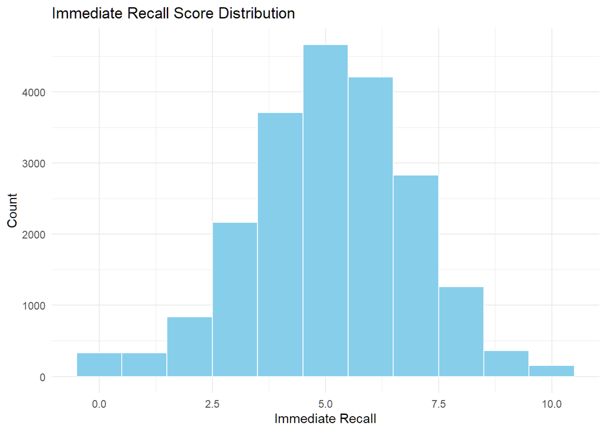

```r
ggplot(df, aes(x = mem_immediate)) +
  geom_histogram(binwidth = 1, fill = "skyblue", color = "white") +
  labs(title = "Immediate Recall Score Distribution", x = "Immediate Recall", y = "Count") +
  theme_minimal()
```

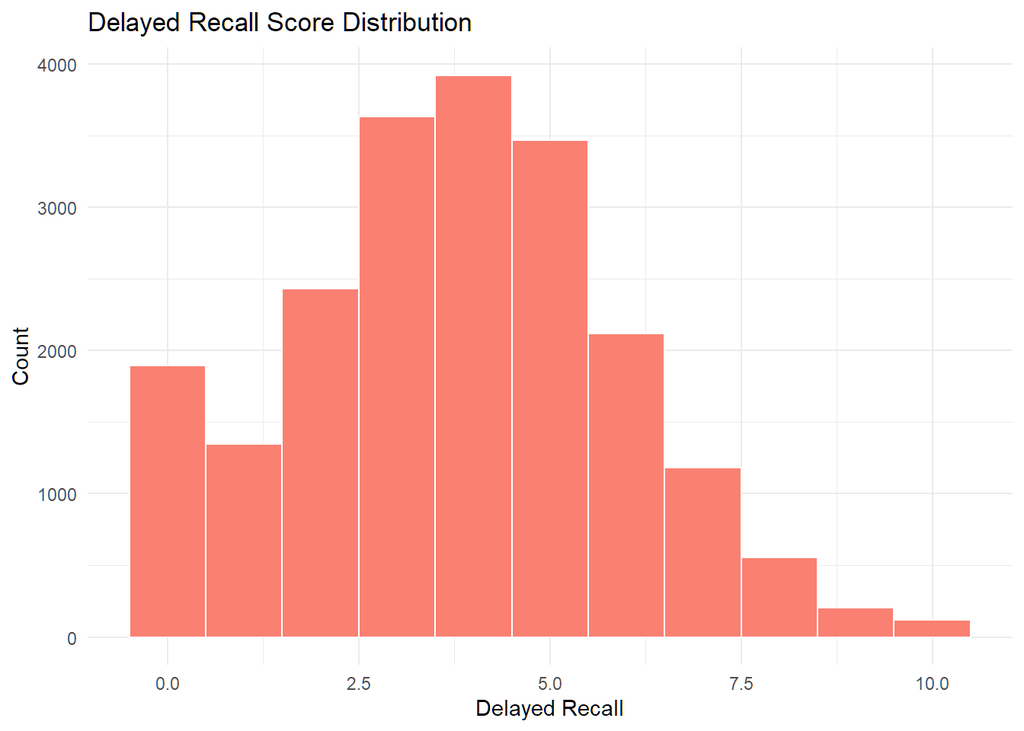

```r
ggplot(df, aes(x = mem_delayed)) +
  geom_histogram(binwidth = 1, fill = "salmon", color = "white") +
  labs(title = "Delayed Recall Score Distribution", x = "Delayed Recall", y = "Count") +
  theme_minimal()
```

# Final Data Selection

```r
df <- df %>%
  dplyr::select(
    child_sig, cog_index, ls,
    age, age_group, gender,
    country,
    edu, edu_label, edu_group,
    health, health_label,
    income, income_group,
    rel_above, rel_below,
    cog_above, cog_below
  ) %>%
  filter(
    !is.na(child_sig),
    !is.na(cog_index),
    !is.na(ls),
    !is.na(age),
    !is.na(age_group),
    !is.na(gender),
    !is.na(country),
    !is.na(edu),
    !is.na(edu_label),
    !is.na(edu_group),
    !is.na(health),
    !is.na(health_label),
    !is.na(income),
    !is.na(income_group),
    !is.na(rel_above),
    !is.na(rel_below),
    !is.na(cog_above),
    !is.na(cog_below)
  )

str(df)
```

```
## tibble [20,892 × 18] (S3: tbl_df/tbl/data.frame)
##  $ child_sig   : num [1:20892] 2 2 3 2 3 3 2 3 3 1 ...
##  $ cog_index   : num [1:20892] -0.73 1.622 0.838 -0.991 0.054 ...
##  $ ls          : dbl+lbl [1:20892]  5,  7,  7,  6, 10,  4,  5,  7,  5,  5,  5,  8,  9, ...
##    ..@ label      : chr "How satisfied with life"
##    ..@ format.spss: chr "F3.0"
##    ..@ labels     : Named num [1:2] -2 -1
##    .. ..- attr(*, "names")= chr [1:2] "Refusal" "Don't know"
##  $ age         : num [1:20892] 52 61 59 56 81 67 53 67 74 51 ...
##  $ age_group   : chr [1:20892] "Under 65" "Under 65" "Under 65" "Under 65" ...
##  $ gender      : Factor w/ 2 levels "male","female": 2 2 2 1 2 1 1 2 2 2 ...
##  $ country     : Factor w/ 27 levels "Austria","Germany",..: 21 21 21 21 21 21 21 21 21 21 ...
##  $ edu         : dbl+lbl [1:20892] 0, 7, 6, 6, 6, 3, 3, 2, 3, 7, 2, 2, 3, 3, 7, 3, 6, 3...
##    ..@ label        : chr "Respondent: ISCED-11 coding of education"
##    ..@ format.spss  : chr "F3.0"
##    ..@ display_width: int 13
##    ..@ labels       : Named num [1:13] -2 -1 0 1 2 3 4 5 6 7 ...
##    .. ..- attr(*, "names")= chr [1:13] "Refusal" "Don't know" "None" "ISCED-11 code 1" ...
##  $ edu_label   : chr [1:20892] "Early childhood" "Master or equivalent" "Bachelor or equivalent" "Bachelor or equivalent" ...
##  $ edu_group   : chr [1:20892] "Low" "High" "High" "High" ...
##  $ health      : num [1:20892] 4 4 3 3 4 4 1 4 5 4 ...
##  $ health_label: chr [1:20892] "Very good" "Very good" "Good" "Good" ...
##  $ income      : num [1:20892] 265.9 869.2 460.2 10.2 143.2 ...
##  $ income_group: int [1:20892] 2 4 3 1 1 3 3 4 1 2 ...
##  $ rel_above   : num [1:20892] 0 0 1 0 1 1 0 1 1 0 ...
##  $ rel_below   : num [1:20892] 1 1 0 1 0 0 1 0 0 1 ...
##  $ cog_above   : num [1:20892] 0 1 1 0 0 1 0 0 0 1 ...
##  $ cog_below   : num [1:20892] 0 0 0 1 0 0 0 0 0 0 ...
```

# Variable Post-Inspection

```r
post_vars <- c("child_sig", "cog_index", "ls", "age", "gender", "country", "edu_group", "health", "income_group")

for (v in post_vars) {
  cat("\n---", v, "---\n")
  print(summary(df[[v]]))
  cat("Valid responses:", sum(!is.na(df[[v]])), "\n")
}
```

```
##
## --- child_sig ---
##    Min. 1st Qu.  Median    Mean 3rd Qu.    Max.
##   1.000   2.000   3.000   2.854   4.000   4.000
## Valid responses: 20892
##
## --- cog_index ---
##     Min.  1st Qu.   Median     Mean  3rd Qu.     Max.
## -2.29771 -0.72989  0.05402  0.02082  0.57663  2.92837
## Valid responses: 20892
##
## --- ls ---
##    Min. 1st Qu.  Median    Mean 3rd Qu.    Max.
##   0.000   6.000   8.000   7.358   9.000  10.000
## Valid responses: 20892
##
## --- age ---
##    Min. 1st Qu.  Median    Mean 3rd Qu.    Max.
##   50.00   58.00   65.00   66.51   74.00  102.00
## Valid responses: 20892
##
## --- gender ---
##   male female
##   8483  12409
## Valid responses: 20892
##
## --- country ---
##        Austria        Germany         Sweden          Spain          Italy
##              0           1681            995            595            918
##         France        Denmark         Greece    Switzerland        Belgium
##            176            924            466              0           1000
##         Israel Czech Republic         Poland     Luxembourg        Hungary
##              0            489           1726            566              0
##       Portugal       Slovenia        Estonia        Croatia      Lithuania
##              0            995            344           1361           1374
##       Bulgaria         Cyprus        Finland         Latvia          Malta
##           1233            713           1151           1036            685
##        Romania       Slovakia
##           1247           1217
## Valid responses: 20892
##
## --- edu_group ---
##    Length     Class      Mode
##     20892 character character
## Valid responses: 20892
##
## --- health ---
##    Min. 1st Qu.  Median    Mean 3rd Qu.    Max.
##   1.000   2.000   3.000   2.723   3.000   5.000
## Valid responses: 20892
##
## --- income_group ---
##    Min. 1st Qu.  Median    Mean 3rd Qu.    Max.
##   1.000   2.000   3.000   2.569   4.000   4.000
## Valid responses: 20892
```

# Save File

```r
write.csv(df, "df_cleaned.csv", row.names = FALSE)
cat("Final sample size:", nrow(df), "\n")
```

```
## Final sample size: 20892
```

# References

[1] SHARE-ERIC (2024). *Survey of Health, Ageing and Retirement in Europe (SHARE) Wave 7*. Release version: 9.0.0. SHARE-ERIC. Data set. DOI: 10.6103/SHARE.w7.900

[2] Bergmann, M., T. Kneip, G. De Luca and A. Scherpenzeel (2019). *Survey participation in the Survey of Health, Ageing and Retirement in Europe (SHARE), Wave 1-7*. Based on Release 7.0.0. SHARE Working Paper Series: 41-2019. Munich: MEA, Max Planck Institute for Social Law and Social Policy.

[3] SHARE-ERIC. (2019). *SHARE Wave 7: Module CF – Cognitive function*. SBI. https://www.share-datadocutool.org/control-construct-schemes/view/161

[4] SHARE-ERIC. (2019). *SHARE Wave 7: Module EX– Expectations*. SBI. https://www.share-datadocutool.org/control-construct-schemes/view/195

[5] SHARE-ERIC. (2019). *SHARE Wave 7: Module CC – Childhood Circumstances*. SBI. https://www.share-datadocutool.org/control-construct-schemes/view/209

[6] SHARE-ERIC. (2019). *SHARE Wave 7: Module AC – Activities*. SBI. https://www.share-datadocutool.org/control-construct-schemes/view/189

# Additional Mandatory References

Bergmann, M., A. Scherpenzeel and A. Börsch-Supan (Eds.) (2019). *SHARE Wave 7 Methodology: Panel Innovations and Life Histories*. Munich: MEA, Max Planck Institute for Social Law and Social Policy.

Börsch-Supan, A., M. Brandt, C. Hunkler, T. Kneip, J. Korbmacher, F. Malter, B. Schaan, S. Stuck and S. Zuber (2013). *Data Resource Profile: The Survey of Health, Ageing and Retirement in Europe (SHARE)*. International Journal of Epidemiology. DOI: [**10.1093/ije/dyt088**](https://doi.org/10.1093/ije/dyt088).